# Entrega no balanceada

# 1. Introducción

El presente trabajo analiza los datos relativos al dataset *CreditCard*. El objetivo es predecir transacciones fraudulentas realizadas con tarjeta de crédito. *Clase* es la variable de respuesta y toma el valor 1 en caso de fraude y 0 en caso contrario.

El dataset está compuesto por 284.807 observaciones y 31 variables. Contiene las transacciones realizadas durante 2 días de Septiembre del 2013 en Europa. Posee sólo variables de entrada numéricas, que son el resultado de un Análisis de Componentes Principales. Desafortunadamente, debido a problemas de confidencialidad, no se pueden proporcionar las características originales sobre los datos. Las únicas características que no se han transformado son las variables Tiempo y Cantidad.

# 2. Importado y limpieza de los datos

Procedemos a importar los datos y realizamos e imprimimos los primeros 5 registros, de manera de tener una primera aproximación a los datos:

```r
df=read.table("creditcard.csv",header=TRUE,sep=",")
head(df)
```

|  | Time | V1 | V2 | V3 | V4 | V5 | V6 | V7 | V8 | V9 | V10 | V11 | V12 | V13 | V14 | V15 | V16 | V17 | V18 | V19 | V20 | V21 | V22 | V23 | V24 | V25 | V26 | V27 | V28 | … |
| --- | --- | --- | --- | --- | --- | --- | --- | --- | --- | --- | --- | --- | --- | --- | --- | --- | --- | --- | --- | --- | --- | --- | --- | --- | --- | --- | --- | --- | --- | --- |
| 1 | 0 | -1.3598071 | -0.07278117 | 2.5363467 | 1.3781552 | -0.33832077 | 0.46238778 | 0.23959855 | 0.09869790 | 0.3637870 | 0.09079417 | -0.5515995 | -0.61780086 | -0.9913898 | -0.3111694 | 1.4681770 | -0.4704005 | 0.20797124 | 0.02579058 | 0.40399296 | 0.25141210 | -0.018306778 | 0.277837576 | -0.11047391 | 0.06692807 | 0.1285394 | -0.1891148 | 0.133558377 | -0.02105305 | … |
| 2 | 0 | 1.1918571 | 0.26615071 | 0.1664801 | 0.4481541 | 0.06001765 | -0.08236081 | -0.07880298 | 0.08510165 | -0.2554251 | -0.16697441 | 1.6127267 | 1.06523531 | 0.4890950 | -0.1437723 | 0.6355581 | 0.4639170 | -0.11480466 | -0.18336127 | -0.14578304 | -0.06908314 | -0.225775248 | -0.638671953 | 0.10128802 | -0.33984648 | 0.1671704 | 0.1258945 | -0.008983099 | 0.01472417 | … |
| 3 | 1 | -1.3583541 | -1.34016307 | 1.7732093 | 0.3797796 | -0.50319813 | 1.80049938 | 0.79146096 | 0.24767579 | -1.5146543 | 0.20764287 | 0.6245015 | 0.06608369 | 0.7172927 | -0.1659459 | 2.3458649 | -2.8900832 | 1.10996938 | -0.12135931 | -2.26185710 | 0.52497973 | 0.247998153 | 0.771679402 | 0.90941226 | -0.68928096 | -0.3276418 | -0.1390966 | -0.055352794 | -0.05975184 | … |
| 4 | 1 | -0.9662717 | -0.18522601 | 1.7929933 | -0.8632913 | -0.01030888 | 1.24720317 | 0.23760894 | 0.37743587 | -1.3870241 | -0.05495192 | -0.2264873 | 0.17822823 | 0.5077569 | -0.2879237 | -0.6314181 | -1.0596472 | -0.68409279 | 1.96577500 | -1.23262197 | -0.20803778 | -0.108300452 | 0.005273597 | -0.19032052 | -1.17557533 | 0.6473760 | -0.2219288 | 0.062722849 | 0.06145763 | … |
| 5 | 2 | -1.1582331 | 0.87773675 | 1.5487178 | 0.4030339 | -0.40719338 | 0.09592146 | 0.59294075 | -0.27053268 | 0.8177393 | 0.75307443 | -0.8228429 | 0.53819555 | 1.3458516 | -1.1196698 | 0.1751211 | -0.4514492 | -0.23703324 | -0.03819479 | 0.80348692 | 0.40854236 | -0.009430697 | 0.798278495 | -0.13745808 | 0.14126698 | -0.2060096 | 0.5022922 | 0.219422230 | 0.21515315 | … |
| 6 | 2 | -0.4259659 | 0.96052304 | 1.1411093 | -0.1682521 | 0.42098688 | -0.02972755 | 0.47620095 | 0.26031433 | -0.5686714 | -0.37140720 | 1.3412620 | 0.35989384 | -0.3580907 | -0.1371337 | 0.5176168 | 0.4017259 | -0.05813282 | 0.06865315 | -0.03319379 | 0.08496767 | -0.208253515 | -0.559824796 | -0.02639767 | -0.37142658 | -0.2327938 | 0.1059148 | 0.253844225 | 0.08108026 | … |

Eliminamos la columna *Tiempo*, ya que no es relevante para realizar la predicción.

```r
df = df[,-1]
df_analisis_exploratorio=df
```

Procedemos a analizar la correlación entre las variables:

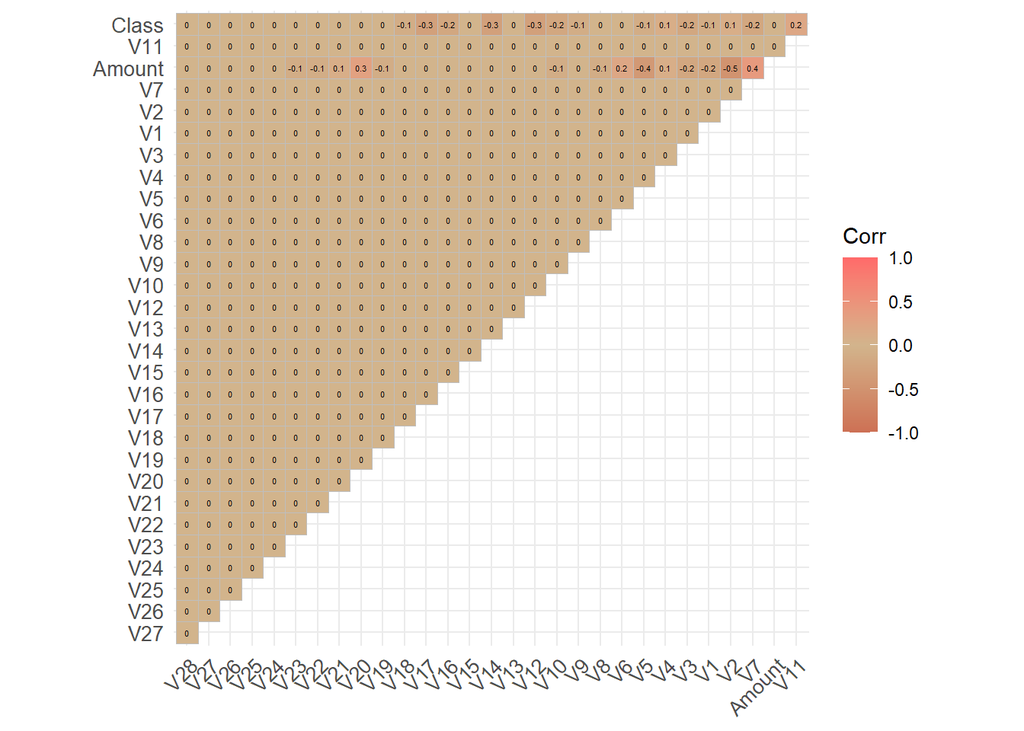

```r
mat.cor = corr.test(df)
M = round(mat.cor$r, 1)
ggcorrplot(M,
           hc.order = TRUE,
           type = "upper",
           tl.cex = 10,
           lab = TRUE,
           lab_size = 1.5,
           colors = c("salmon3", "tan", "indianred1"))
```

Vemos que no hay multicolinealidad lineal perfecta (>0.7) entre las variables.

A continuación escalamos las variables:

```r
df <- df %>% mutate_at(c(1:29), ~(scale(.) %>% as.vector))
summary(df)
```

```
       V1                   V2                  V3                 V4
 Min.   :-28.798504   Min.   :-44.03521   Min.   :-31.8717   Min.   :-4.01391
 1st Qu.: -0.469891   1st Qu.: -0.36247   1st Qu.: -0.5872   1st Qu.:-0.59938
 Median :  0.009245   Median :  0.03966   Median :  0.1186   Median :-0.01402
 Mean   :  0.000000   Mean   :  0.00000   Mean   :  0.0000   Mean   : 0.00000
 3rd Qu.:  0.671693   3rd Qu.:  0.48672   3rd Qu.:  0.6775   3rd Qu.: 0.52501
 Max.   :  1.253349   Max.   : 13.35773   Max.   :  6.1880   Max.   :11.91872
       V5                  V6                 V7                  V8
 Min.   :-82.40795   Min.   :-19.6360   Min.   :-35.20933   Min.   :-61.30242
 1st Qu.: -0.50107   1st Qu.: -0.5767   1st Qu.: -0.44789   1st Qu.: -0.17468
 Median : -0.03937   Median : -0.2058   Median :  0.03242   Median :  0.01872
 Mean   :  0.00000   Mean   :  0.0000   Mean   :  0.00000   Mean   :  0.00000
 3rd Qu.:  0.44335   3rd Qu.:  0.2992   3rd Qu.:  0.46111   3rd Qu.:  0.27408
 Max.   : 25.21409   Max.   : 55.0200   Max.   : 97.47807   Max.   : 16.75150
       V9                 V10                 V11                V12
 Min.   :-12.22799   Min.   :-22.58187   Min.   :-4.70012   Min.   :-18.6986
 1st Qu.: -0.58536   1st Qu.: -0.49173   1st Qu.:-0.74702   1st Qu.: -0.4059
 Median : -0.04681   Median : -0.08533   Median :-0.03209   Median :  0.1401
 Mean   :  0.00000   Mean   :  0.00000   Mean   : 0.00000   Mean   :  0.0000
 3rd Qu.:  0.54353   3rd Qu.:  0.41688   3rd Qu.: 0.72459   3rd Qu.:  0.6187
 Max.   : 14.19492   Max.   : 21.80754   Max.   :11.77502   Max.   :  7.8547
      V13                V14                 V15                V16
 Min.   :-5.81938   Min.   :-20.04425   Min.   :-4.91518   Min.   :-16.12532
 1st Qu.:-0.65162   1st Qu.: -0.44396   1st Qu.:-0.63681   1st Qu.: -0.53413
 Median :-0.01363   Median :  0.05279   Median : 0.05252   Median :  0.07579
 Mean   : 0.00000   Mean   :  0.00000   Mean   : 0.00000   Mean   :  0.00000
 3rd Qu.: 0.66565   3rd Qu.:  0.51445   3rd Qu.: 0.70885   3rd Qu.:  0.59720
 Max.   : 7.16072   Max.   : 10.98145   Max.   : 9.69910   Max.   : 19.76040
      V17                 V18                  V19
 Min.   :-29.62640   Min.   :-11.332636   Min.   :-8.861386
 1st Qu.: -0.56956   1st Qu.: -0.595161   1st Qu.:-0.560536
 Median : -0.07733   Median : -0.004338   Median : 0.004588
 Mean   :  0.00000   Mean   :  0.000000   Mean   : 0.000000
 3rd Qu.:  0.47057   3rd Qu.:  0.597496   3rd Qu.: 0.563792
 Max.   : 10.89500   Max.   :  6.014331   Max.   : 6.869402
      V20                 V21                 V22
 Min.   :-70.69134   Min.   :-47.41898   Min.   :-15.065620
 1st Qu.: -0.27463   1st Qu.: -0.31094   1st Qu.: -0.747346
 Median : -0.08105   Median : -0.04009   Median :  0.009345
 Mean   :  0.00000   Mean   :  0.00000   Mean   :  0.000000
 3rd Qu.:  0.17257   3rd Qu.:  0.25374   3rd Qu.:  0.728335
 Max.   : 51.13455   Max.   : 37.03465   Max.   : 14.473016
      V23                 V24                V25                 V26
 Min.   :-71.75434   Min.   :-4.68363   Min.   :-19.75030   Min.   :-5.4011
 1st Qu.: -0.25918   1st Qu.:-0.58547   1st Qu.: -0.60840   1st Qu.:-0.6781
 Median : -0.01792   Median : 0.06766   Median :  0.03183   Median :-0.1081
 Mean   :  0.00000   Mean   : 0.00000   Mean   :  0.00000   Mean   : 0.0000
 3rd Qu.:  0.23643   3rd Qu.: 0.72571   3rd Qu.:  0.67280   3rd Qu.: 0.4997
 Max.   : 36.07661   Max.   : 7.56967   Max.   : 14.42529   Max.   : 7.2940
      V27                 V28                Amount              Class
 Min.   :-55.90650   Min.   :-46.74604   Min.   : -0.35323   Min.   :0.000000
 1st Qu.: -0.17551   1st Qu.: -0.16044   1st Qu.: -0.33084   1st Qu.:0.000000
 Median :  0.00333   Median :  0.03406   Median : -0.26527   Median :0.000000
 Mean   :  0.00000   Mean   :  0.00000   Mean   :  0.00000   Mean   :0.001728
 3rd Qu.:  0.22556   3rd Qu.:  0.23715   3rd Qu.: -0.04472   3rd Qu.:0.000000
 Max.   : 78.31926   Max.   :102.54324   Max.   :102.36206   Max.   :1.000000
```

Observamos que el dataset no posee *NA`s*:

```r
colSums(is.na(df))
```

```
    V1     V2     V3     V4     V5     V6     V7     V8     V9    V10    V11
     0      0      0      0      0      0      0      0      0      0      0
   V12    V13    V14    V15    V16    V17    V18    V19    V20    V21    V22
     0      0      0      0      0      0      0      0      0      0      0
   V23    V24    V25    V26    V27    V28 Amount  Class
     0      0      0      0      0      0      0      0
```

Por último, convertimos a factor la variable target:

```r
df$Class=as.factor(df$Class)
levels(df$Class)=c("0","1")
```

# 3. Análisis exploratorio de los datos

El dataset contiene 284.807 observaciones y 31 variables. Estas van de forma consecutiva desde *V1* hasta *V28*. Asimismo, tenemos la columna *Class*, que indica si la transacción es fraudulenta (1) o no (0) y la columna *Amount*, que indica el monto de las transacciones realizadas.

Vemos que en nuestro dataset hay 284.315 (99,82%) transacciones no fraudulentas y 492 que lo son (0,17%). Esto quiere decir que hay 577 registros de la clase mayoritaria por cada uno de la clase minoritaria.

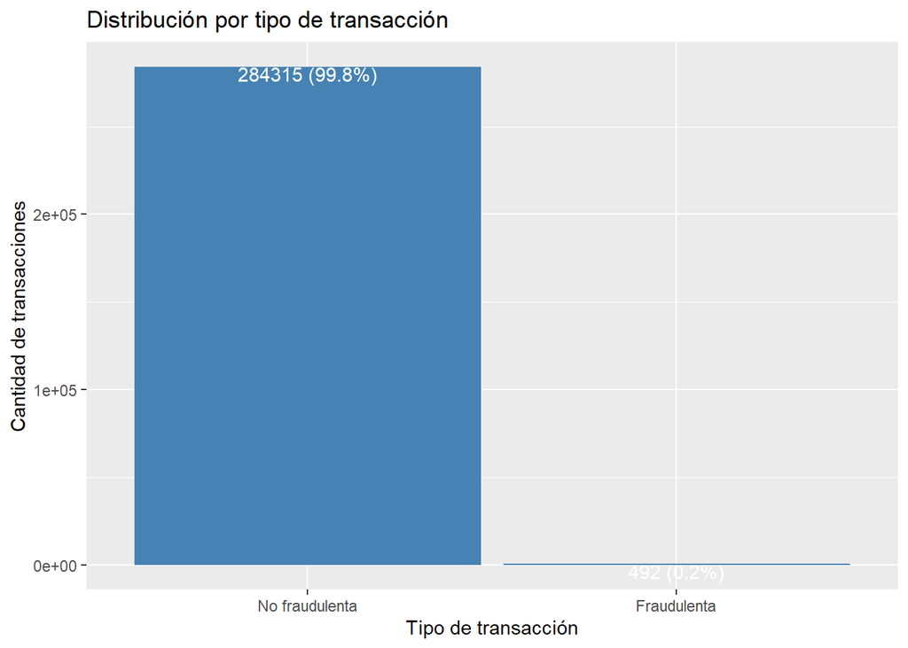

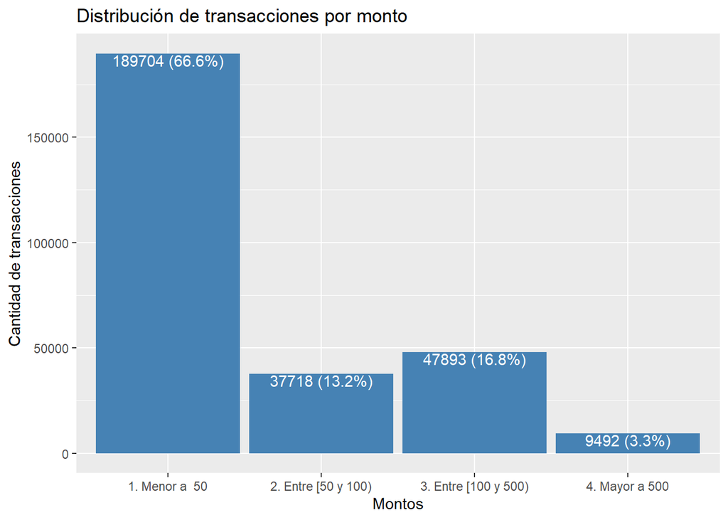

Vemos que la mayor parte de las transacciones 189.704 (66.6%) corresponden a montos menores 50, seguido de aquellas entre [100 y 500), que alcanzan 47.893 transacciones (16,8%). Las transacciones de entre [50 y 100) totalizan 37.718 (13.2%). Vemos por último, que las mayores a 500 representan solo el 3,3%.

Si analizamos ahora la distribución combinando monto de la transacción y clase, vemos que hay una mayor proporción de operaciones fraudulentas entre [100 y 500] (estas representan el 19,3% en las fraudulentas vs 16,8% en las no fraudulentas) y en aquellas de más de 500 (7,1% de las fraudulentas vs 3.3% en no fraudulentas).

```
      1. Menor a  50  2. Entre [50 y 100) 3. Entre [100 y 500)
          0.61991870           0.11585366           0.19308943
      4. Mayor a 500
          0.07113821
```

```
      1. Menor a  50  2. Entre [50 y 100) 3. Entre [100 y 500)
           0.6661590            0.1324622            0.1681163
      4. Mayor a 500
           0.0332624
```

Debajo realizamos un summary del dataframe, de modo de poder observar las principales características relativas a los valores y a la distribución de las variables. Debido a que las variables que van desde *V1* a *V28* son producto del análisis de componentes principales y por lo tanto desconocemos qué representan, no nos es posible realizar un análisis pormenorizado de las mismas.

|  | V1 | V2 | V3 | V4 | V5 | V6 | V7 | V8 | V9 | V10 | V11 | V12 | V13 | V14 | V15 | V16 | V17 | V18 | V19 | V20 | V21 | V22 | V23 | V24 | V25 | V26 | V27 | V28 | Amount | … |
| --- | --- | --- | --- | --- | --- | --- | --- | --- | --- | --- | --- | --- | --- | --- | --- | --- | --- | --- | --- | --- | --- | --- | --- | --- | --- | --- | --- | --- | --- | --- |
|  | Min. :-56.40751 | Min. :-72.71573 | Min. :-48.3256 | Min. :-5.68317 | Min. :-113.74331 | Min. :-26.1605 | Min. :-43.5572 | Min. :-73.21672 | Min. :-13.43407 | Min. :-24.58826 | Min. :-4.79747 | Min. :-18.6837 | Min. :-5.79188 | Min. :-19.2143 | Min. :-4.49894 | Min. :-14.12985 | Min. :-25.16280 | Min. :-9.498746 | Min. :-7.213527 | Min. :-54.49772 | Min. :-34.83038 | Min. :-10.933144 | Min. :-44.80774 | Min. :-2.83663 | Min. :-10.29540 | Min. :-2.60455 | Min. :-22.565679 | Min. :-15.43008 | Min. : 0.00 | … |
|  | 1st Qu.: -0.92037 | 1st Qu.: -0.59855 | 1st Qu.: -0.8904 | 1st Qu.:-0.84864 | 1st Qu.: -0.69160 | 1st Qu.: -0.7683 | 1st Qu.: -0.5541 | 1st Qu.: -0.20863 | 1st Qu.: -0.64310 | 1st Qu.: -0.53543 | 1st Qu.:-0.76249 | 1st Qu.: -0.4056 | 1st Qu.:-0.64854 | 1st Qu.: -0.4256 | 1st Qu.:-0.58288 | 1st Qu.: -0.46804 | 1st Qu.: -0.48375 | 1st Qu.:-0.498850 | 1st Qu.:-0.456299 | 1st Qu.: -0.21172 | 1st Qu.: -0.22839 | 1st Qu.: -0.542350 | 1st Qu.: -0.16185 | 1st Qu.:-0.35459 | 1st Qu.: -0.31715 | 1st Qu.:-0.32698 | 1st Qu.: -0.070840 | 1st Qu.: -0.05296 | 1st Qu.: 5.60 | … |
|  | Median : 0.01811 | Median : 0.06549 | Median : 0.1799 | Median :-0.01985 | Median : -0.05434 | Median : -0.2742 | Median : 0.0401 | Median : 0.02236 | Median : -0.05143 | Median : -0.09292 | Median :-0.03276 | Median : 0.1400 | Median :-0.01357 | Median : 0.0506 | Median : 0.04807 | Median : 0.06641 | Median : -0.06568 | Median :-0.003636 | Median : 0.003735 | Median : -0.06248 | Median : -0.02945 | Median : 0.006782 | Median : -0.01119 | Median : 0.04098 | Median : 0.01659 | Median :-0.05214 | Median : 0.001342 | Median : 0.01124 | Median : 22.00 | … |
|  | Mean : 0.00000 | Mean : 0.00000 | Mean : 0.0000 | Mean : 0.00000 | Mean : 0.00000 | Mean : 0.0000 | Mean : 0.0000 | Mean : 0.00000 | Mean : 0.00000 | Mean : 0.00000 | Mean : 0.00000 | Mean : 0.0000 | Mean : 0.00000 | Mean : 0.0000 | Mean : 0.00000 | Mean : 0.00000 | Mean : 0.00000 | Mean : 0.000000 | Mean : 0.000000 | Mean : 0.00000 | Mean : 0.00000 | Mean : 0.000000 | Mean : 0.00000 | Mean : 0.00000 | Mean : 0.00000 | Mean : 0.00000 | Mean : 0.000000 | Mean : 0.00000 | Mean : 88.35 | … |
|  | 3rd Qu.: 1.31564 | 3rd Qu.: 0.80372 | 3rd Qu.: 1.0272 | 3rd Qu.: 0.74334 | 3rd Qu.: 0.61193 | 3rd Qu.: 0.3986 | 3rd Qu.: 0.5704 | 3rd Qu.: 0.32735 | 3rd Qu.: 0.59714 | 3rd Qu.: 0.45392 | 3rd Qu.: 0.73959 | 3rd Qu.: 0.6182 | 3rd Qu.: 0.66251 | 3rd Qu.: 0.4931 | 3rd Qu.: 0.64882 | 3rd Qu.: 0.52330 | 3rd Qu.: 0.39968 | 3rd Qu.: 0.500807 | 3rd Qu.: 0.458949 | 3rd Qu.: 0.13304 | 3rd Qu.: 0.18638 | 3rd Qu.: 0.528554 | 3rd Qu.: 0.14764 | 3rd Qu.: 0.43953 | 3rd Qu.: 0.35072 | 3rd Qu.: 0.24095 | 3rd Qu.: 0.091045 | 3rd Qu.: 0.07828 | 3rd Qu.: 77.17 | … |
|  | Max. : 2.45493 | Max. : 22.05773 | Max. : 9.3826 | Max. :16.87534 | Max. : 34.80167 | Max. : 73.3016 | Max. :120.5895 | Max. : 20.00721 | Max. : 15.59500 | Max. : 23.74514 | Max. :12.01891 | Max. : 7.8484 | Max. : 7.12688 | Max. : 10.5268 | Max. : 8.87774 | Max. : 17.31511 | Max. : 9.25353 | Max. : 5.041069 | Max. : 5.591971 | Max. : 39.42090 | Max. : 27.20284 | Max. : 10.503090 | Max. : 22.52841 | Max. : 4.58455 | Max. : 7.51959 | Max. : 3.51735 | Max. : 31.612198 | Max. : 33.84781 | Max. :25691.16 | … |

# 4. Modelado

En primer lugar se deben crear dos subsets, uno de *training* y otro de *testing*, para entrenar y testear los modelos. Asimismo, se aplica una semilla al inicio, de manera de hacer los resultados replicables.

Dividimos los datos de la siguiente manera:

- 75% train
- 25% test

```r
set.seed(2021)
muestra.train=sample(1:dim(df)[1],round(dim(df)[1]*0.75),replace=FALSE)
df.train=df[muestra.train,]
muestra.test=setdiff(1:dim(df)[1],muestra.train)
df.test=df[muestra.test,]
```

A continuación aplicamos los siguientes modelos de clasificación:

-Logistic Regression

-Quadratic Discriminant Analysis (QDA)

-Naive Bayes

-Árboles

Realizamos una breve descripción de cada modelo:

*Logistic Regression*: Este método permite estimar la probabilidad de una variable cualitativa binaria en función de una variable cuantitativa. La regresión logística permite calcular la probabilidad de que la variable dependiente pertenezca a cada una de las dos categorías en función del valor que adquiera la variable independiente.

*Quadratic Discriminant Analysis (QDA)*: Esta metodología es similar a LDA, con la diferencia de que el QDA considera que cada clase k tiene su propia matriz de covarianza y, como consecuencia, la función discriminante toma forma cuadrática.

*Naive Bayes*: El algoritmo Bayes naive es un algoritmo de clasificación de variables cualitativas basado en los teoremas de Bayes. Este algoritmo es llamado “ingenuo” porque calcula las probabilidades condicionales por separado, como si fueran independientes una de otra. Una vez que se obtienen las probabilidades condicionales por separado, se calcula la probabilidad conjunta de todas ellas, mediante un producto, para determinar la probabilidad de que pertenezca a la categoría. Luego se itera dicho proceso para cada observación.

*Árboles*: Mediante este modelo se intenta predecir una variable dependiente a partir de variables independientes. Existen árboles de clasificación (variable discreta) y árboles de regresión (variable continua). Lo que hace este algoritmo es encontrar la variable independiente que mejor separa nuestros datos en grupos, que corresponden con las categorías de la variable objetivo. Esta mejor separación es expresada con una regla. A cada regla corresponde un nodo.

Una vez hecho esto, los datos son separados (particionados) en grupos a partir de la regla obtenida. Después, para cada uno de los grupos resultantes, se repite el mismo proceso. Se busca la variable que mejor separa los datos en grupos, se obtiene una regla, y se separan los datos. Hacemos esto de manera recursiva hasta que nos es imposible obtener una mejor separación. Cuando esto ocurre, el algoritmo se detiene. Cuando un grupo no puede ser partido mejor, se le llama nodo terminal u hoja.

Las métricas que utilizaremos para evaluar el rendimiento de los modelos son las siguientes:

*Recall (TPR)*:

$$\text {Recall = Verdaderos positivos / (Verdaderos positivos + Falsos negativos) }$$
Es una forma de analizar la tasa de verdaderos positivos. Si su valor es bajo, quiere decir que hay muchos falsos negativos, lo que implica que muchas transacciones fraudulentas no fueron detectadas. Esta es la principal métrica dentro de nuestro estudio.

*Precision*:

$$\text {Precision = Verdaderos positivos / (Verdaderos positivos + Falsos positivos) }$$
Si se obtiene un valor reducido, querrá decir que hay muchos falsos positivos, es decir que hemos levantado sospechas sobre transacciones no fraudulentas. Si bien se desean evitar estas situaciones ya que posee un costo económico (el banco deberá comunicarse con el cliente para corroborar la operación y realizar un análisis en profundidad de la misma), es de menor gravedad que el caso planteado en el apartado anterior.

*F*:

$$\text {Prueba F = (2 * Precision * Recall) / (Recall + Precision) }$$
Es la media armónica de las anteriores métricas.

Métodos a aplicar:

*Oversampling*: Las técnicas de oversampling buscan generar nuevos valores de la clase minoritaria a la hora de entrenar los modelos, de manera tal que estos sean capaces de predecir mejor en datasets desbalanceados como el nuestro. En nuestro caso utilizaremos el método *Smote*, creando 2, 6, 15, 50 y 80 datos nuevos por cada uno ya existente de la clase minoritaria.

*Undesampling*: Las técnicas de undersampling buscan eliminar datos de la clase mayoritaria a la hora de entrenar el modelo. En nuestro caso utilizaremos la función tomek link para dicho fin. Dicha función, busca los valores de la clase mayoritaria más cercanos a los de la clase minoritaria y los elimina.

*Función de coste*: En la clasificación regular, el objetivo es minimizar la tasa de clasificación errónea y, por lo tanto, todos los tipos de errores se consideran igualmente graves. En cambio, en la clasificación sensible al costo, los errores no se suponen iguales y el objetivo es minimizar el costo esperado.

En nuestro caso supondremos que el mayor costo está vinculado a no detectar operaciones fraudulentas (C = 5), seguido de predecir fraudes cuando no los hay (C = 1). Por último, no se le ha asignado ningun costo a predecir correctamente para simplificar.

```
                      Fraudulento (Pred) No fraudulento (Pred)
Fraudulento (Real)                     0                     5
No fraudulento (Real)                  1                     0
```

### Árbol

A continuación se procede a entrenar, predecir, y evaluar, el modelo de árboles de clasificación. El primero de ellos será sin realizar balanceo:

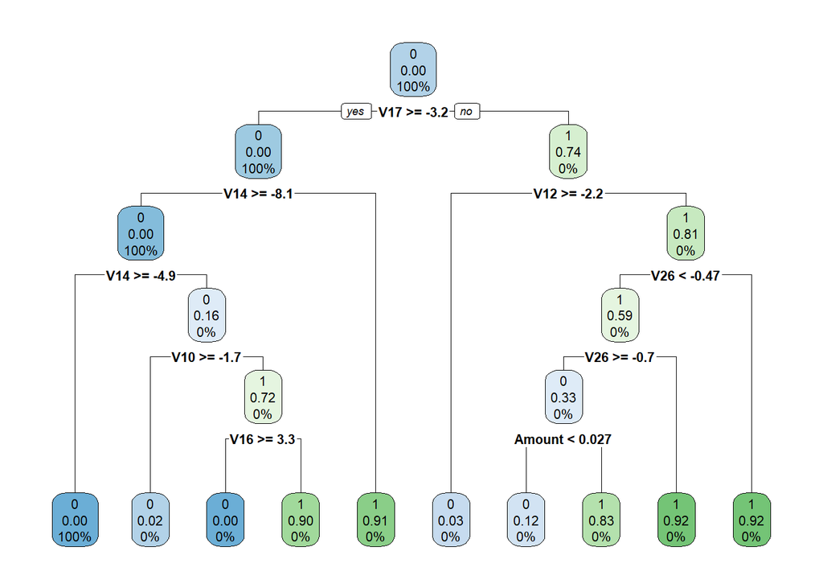

```r
set.seed(2021)

arbol=rpart(Class ~ ., data = df.train)
rpart.plot(arbol)
```

A continuación explicamos la rama derecha del plot, que aglutina a menos del 1% de los registros. Observamos que en primer lugar el árbol evalúa el valor de *V17*. Si es menor que -3.2 la etiqueta correspondiente es de la clase minoritaria. En esta instancia, hay un 74% de los datos que corresponden a la clase minoritaria (fraude). Se procede luego a analizar si *V12* es mayor o igual a -2.2. En caso de ser así, la etiqueta a aplicar es la de la clase mayoritaria. En este subgrupo hay un 3% de los datos que quedarían mal etiquetados, ya que pertenecen a la clase minoritaria. Si en cambio el valor de *V12* es menor a -2.2, la etiqueta es la correspondiente a la clase minoritaria (81% de los datos son de la clase minoritaria). Luego se analiza el valor de *V26*, si no es menor a -0.47, entonces se clasifica como de la clase minoritaria (92% de los valores de esta instancia lo son). Caso contrario, se evalúa el valor de *V26* nuevamente. En caso de que no sea mayor o igual a -0.7, los datos se clasifican como de la clase minoritaria. El 92% de los datos se corresponden a transacciones fraudulentas, lo que quiere decir que el 8% será mal clasificado. En caso contrario, se evalúa si *Amount* es menor a 0.027. En caso afirmativo, la etiqueta sera de transacción no fraudulenta (aunque el 12% de las transacciones lo son), mientras que en el caso contrario se clasifica de fraudulenta (83% de las transacciones lo son).

```r
prediccion=predict(arbol, newdata = df.test)
pred_qual=rep("0",dim(prediccion)[1])
pred_qual[prediccion[,2]>=0.5]="1"
pred_qual=as.factor(pred_qual)

conf_matrix_tree = confusionMatrix(pred_qual, df.test$Class, mode = "prec_recall", positive = "1")

aprec=conf_matrix_tree$byClass[[5]]
arecall=conf_matrix_tree$byClass[[6]]
af= conf_matrix_tree$byClass[[7]]
```

Obtenemos una *Precision* de 0.8611111, un *recall* de 0.775 y una medida *F* de 0.8157895

A continuación realizamos *undersampling*:

```r
set.seed(2021)

X=df.train[,-30]
Y=df.train$Class
res_TOMEK=ubTomek(X, Y, verbose = TRUE)
```

```
Instances removed 76 : 0.04 % of 0 class ; 0.04 % of training ; Time needed 1.41
```

```r
df.train3=data.frame(res_TOMEK$X,Class=res_TOMEK$Y)
arbol=rpart(Class ~ ., data = df.train3)
#rpart.plot(arbol)
prediccion=predict(arbol, newdata = df.test)
pred_qual=rep("0",dim(prediccion)[1])
pred_qual[prediccion[,2]>=0.5]="1"
pred_qual=as.factor(pred_qual)

conf_matrix_tree_tomek = confusionMatrix(pred_qual, df.test$Class, mode = "prec_recall", positive = "1")

aprec_tomek=conf_matrix_tree_tomek$byClass[[5]]
arecall_tomek=conf_matrix_tree_tomek$byClass[[6]]
af_tomek= conf_matrix_tree_tomek$byClass[[7]]
```

Obtenemos una *Precision* de 0.8545455, un *recall* de 0.7833333 y una medida *F* de 0.8173913

A continuación repetimos la operación con una *función de coste:*

```r
set.seed(2021)
tree_opt = rpart(Class ~ ., data = df.train, method = "class", parms=list(loss=c(0,5,1,0)))

prediccion=predict(tree_opt, newdata = df.test, type = "class")


conf_matrix_tree_opt <- caret::confusionMatrix(prediccion, df.test$Class, positive = "1", mode = "everything")

afcost_prec = conf_matrix_tree_opt$byClass[[5]]
afcost_recall = conf_matrix_tree_opt$byClass[[6]]
afcost_f = conf_matrix_tree_opt$byClass[[7]]
```

Obtenemos una *Precision* de 0.8290598, un *recall* de 0.8083333 y una medida *F* de 0.8185654

A continuación realizamos diversas pruebas de ajuste de *oversampling*:

```r
# set.seed(2021)
#
# X=df.train[,-30]
# Y=df.train$Class
# nei= c(5,10)
# over= c(200,600,1500,5000,8000)
#
# t=0
# for (knei in nei) {
#   for (perc.over in over) {
#       t=t+1
#       res_SMOTE=ubSMOTE(X, Y, perc.over = perc.over, k = knei, perc.under = 0, verbose = TRUE)
#       df.train2=rbind(df.train,data.frame(res_SMOTE$X,Class=res_SMOTE$Y))
#       arbol=rpart(Class ~ ., data = df.train2)
#       prediccion=predict(arbol, newdata = df.test)
#       pred_qual=rep("0",dim(prediccion)[1])
#       pred_qual[prediccion[,2]>=0.5]="1"
#       pred_qual=as.factor(pred_qual)
#
#       conf_matrix_tree = confusionMatrix(pred_qual, df.test$Class, mode = "prec_recall", positive = "1")
#       precision=conf_matrix_tree$byClass[[5]]
#       recall=conf_matrix_tree$byClass[[6]]
#       f=conf_matrix_tree$byClass[[7]]
#
#       if (t==1){
#         resultados = data.frame("oversampling", knei, perc.over,precision,recall, f)
#         print(t)
#   }
#       else {
#         resultados[t,] = data.frame("oversampling",knei, perc.over,precision,recall, f)
#         print(t)
# }
# }
# }
#
# resultados[t+1,] = data.frame("sin balanceo", "NA", "NA", aprec, arecall, af)
# resultados[t+2,] = data.frame("tomek-link", "NA", "NA", aprec_tomek, arecall_tomek, af_tomek)
# resultados[t+3,] = data.frame("funcion de coste", "NA", "NA", afcost_prec, afcost_recall, afcost_f)
#
# colnames(resultados)= c("Técnica", "K vecinos", "perc.over", "Precision", "Recall", "F")
# print(resultados)
# write.csv(resultados,"resultadostree.csv")
read.csv("resultadostree.csv")
```

| X | Técnica | K.vecinos | perc.over | Precision | Recall | F |
| --- | --- | --- | --- | --- | --- | --- |
| 1 | oversampling | 5 | 200 | 0.8151261 | 0.8083333 | 0.8117155 |
| 2 | oversampling | 5 | 600 | 0.7920000 | 0.8250000 | 0.8081633 |
| 3 | oversampling | 5 | 1500 | 0.6875000 | 0.8250000 | 0.7500000 |
| 4 | oversampling | 5 | 5000 | 0.5444444 | 0.8166667 | 0.6533333 |
| 5 | oversampling | 5 | 8000 | 0.5185185 | 0.8166667 | 0.6343042 |
| 6 | oversampling | 10 | 200 | 0.8151261 | 0.8083333 | 0.8117155 |
| 7 | oversampling | 10 | 600 | 0.7500000 | 0.8250000 | 0.7857143 |
| 8 | oversampling | 10 | 1500 | 0.6875000 | 0.8250000 | 0.7500000 |
| 9 | oversampling | 10 | 5000 | 0.4694836 | 0.8333333 | 0.6006006 |
| 10 | oversampling | 10 | 8000 | 0.3952569 | 0.8333333 | 0.5361930 |

[output cut: 3 more lines]

Resultados:

Se observa que el mejor desempeño se logra con el modelo de *función de coste*, el cual logra una *F* de 0.8185, un *Recall* 0.8083, y una *Precision* 0.8290. Si bien se observa que hay resultados con una mejor *Recall* (métrica clave en nuestro análisis ya que un bajo valor representa que hay muchas transacciones fraudulentas no detectadas), estás poseen valores muy bajos para la *Precision* y por lo tanto para la *F*.

### Logistic regression

En primer término se procede a entrenar el modelo y a evaluar sus coeficientes sin balancear:

```r
set.seed(2021)
glm.fit=glm(Class~.,data=df.train, family=binomial)
summary(glm.fit)
```

```
Call:
glm(formula = Class ~ ., family = binomial, data = df.train)

Deviance Residuals:
    Min       1Q   Median       3Q      Max
-4.5993  -0.0291  -0.0193  -0.0124   4.5930

Coefficients:
             Estimate Std. Error z value Pr(>|z|)
(Intercept) -8.670276   0.163536 -53.017  < 2e-16 ***
V1           0.174130   0.092363   1.885  0.05939 .
V2          -0.076518   0.097706  -0.783  0.43354
V3           0.070933   0.078450   0.904  0.36590
V4           0.923107   0.110269   8.371  < 2e-16 ***
V5           0.048529   0.098001   0.495  0.62047
V6          -0.108518   0.112054  -0.968  0.33282
V7          -0.152444   0.090552  -1.684  0.09228 .
V8          -0.187572   0.041552  -4.514 6.36e-06 ***
V9          -0.362885   0.131340  -2.763  0.00573 **
V10         -0.860047   0.115893  -7.421 1.16e-13 ***
V11         -0.115337   0.089145  -1.294  0.19573
V12          0.101613   0.100143   1.015  0.31026
V13         -0.415462   0.095324  -4.358 1.31e-05 ***
V14         -0.631896   0.070090  -9.015  < 2e-16 ***
V15          0.005129   0.088906   0.058  0.95400
V16         -0.177104   0.115422  -1.534  0.12493
V17          0.045940   0.065572   0.701  0.48355
V18         -0.010942   0.113714  -0.096  0.92334
V19          0.074918   0.085765   0.874  0.38238
V20         -0.337390   0.073844  -4.569 4.90e-06 ***
V21          0.257190   0.049997   5.144 2.69e-07 ***
V22          0.435403   0.105553   4.125 3.71e-05 ***
V23         -0.040756   0.040204  -1.014  0.31071
V24          0.109917   0.102627   1.071  0.28416
V25         -0.003277   0.076323  -0.043  0.96575
V26         -0.059751   0.106130  -0.563  0.57344
V27         -0.313290   0.060257  -5.199 2.00e-07 ***
V28         -0.105050   0.032877  -3.195  0.00140 **
Amount       0.200717   0.097222   2.065  0.03897 *
---
Signif. codes:  0 '***' 0.001 '**' 0.01 '*' 0.05 '.' 0.1 ' ' 1

(Dispersion parameter for binomial family taken to be 1)

    Null deviance: 5470.0  on 213604  degrees of freedom
Residual deviance: 1688.3  on 213575  degrees of freedom
AIC: 1748.3

Number of Fisher Scoring iterations: 11
```

```r
glm.fit=glm(Class~V4+V8+V10+V13+V14+V16+V20+V21+V22+V27+V28,data=df.train,
            family=binomial)
summary(glm.fit)
```

```
Call:
glm(formula = Class ~ V4 + V8 + V10 + V13 + V14 + V16 + V20 +
    V21 + V22 + V27 + V28, family = binomial, data = df.train)

Deviance Residuals:
    Min       1Q   Median       3Q      Max
-4.6683  -0.0294  -0.0199  -0.0132   4.3411

Coefficients:
            Estimate Std. Error z value Pr(>|z|)
(Intercept) -8.54286    0.14469 -59.043  < 2e-16 ***
V4           0.88743    0.07461  11.894  < 2e-16 ***
V8          -0.21016    0.02586  -8.128 4.36e-16 ***
V10         -0.64031    0.08632  -7.418 1.19e-13 ***
V13         -0.39859    0.08834  -4.512 6.41e-06 ***
V14         -0.63453    0.04823 -13.157  < 2e-16 ***
V16         -0.12566    0.05383  -2.335  0.01957 *
V20         -0.12640    0.04013  -3.150  0.00163 **
V21          0.23821    0.04223   5.641 1.69e-08 ***
V22          0.42380    0.09369   4.523 6.09e-06 ***
V27         -0.15430    0.05355  -2.881  0.00396 **
V28         -0.06907    0.03367  -2.051  0.04024 *
---
Signif. codes:  0 '***' 0.001 '**' 0.01 '*' 0.05 '.' 0.1 ' ' 1

(Dispersion parameter for binomial family taken to be 1)

    Null deviance: 5470.0  on 213604  degrees of freedom
Residual deviance: 1713.9  on 213593  degrees of freedom
AIC: 1737.9

Number of Fisher Scoring iterations: 11
```

Se pone de manifiesto que en el nuevo modelo son todas variables relevantes al 5% de significatividad.

Se procede a realizar la predicción con los datos de testeo:

```r
glm.probs = predict(glm.fit, newdata = df.test, type = "response")
glm.pred = as.factor(ifelse(glm.probs>0.5,1,0))
```

Se evalúa el rendimiento del modelo:

```r
conf_matrix_glm = confusionMatrix(glm.pred, df.test$Class, mode = "prec_recall", positive = "1")

glm= c("sin balanceo","NA","NA", conf_matrix_glm$byClass[[5]], conf_matrix_glm$byClass[[6]], conf_matrix_glm$byClass[[7]])
```

Obtenemos una *Precision* de 0.8831169, un *recall* de 0.5666667 y una medida *F* de 0.6903553

A continuación replicamos haciendo *undersampling*:

```r
set.seed(2021)

res_TOMEK=ubTomek(X, Y, verbose = TRUE)
```

```
Instances removed 76 : 0.04 % of 0 class ; 0.04 % of training ; Time needed 1.37
```

```r
df.train3=data.frame(res_TOMEK$X,Class=res_TOMEK$Y)
#glm.fit=glm(Class~.,data=df.train3, family=binomial)
#summary(glm.fit)
glm.fit=glm(Class~V4+V8+V10+V13+V14+V20+V21+V22+V27+V28,data=df.train3,family=binomial)
#summary(glm.fit)
glm.probs = predict(glm.fit, newdata = df.test, type = "response")
glm.pred = as.factor(ifelse(glm.probs>0.5,1,0))

conf_matrix_treetomek = confusionMatrix(glm.pred, df.test$Class, mode = "prec_recall", positive = "1")

glm_tomek= c("tomek link","NA","NA", conf_matrix_treetomek$byClass[[5]], conf_matrix_treetomek$byClass[[6]], conf_matrix_treetomek$byClass[[7]])
```

Obtenemos una *Precision* de 0.85, un *recall* de 0.5666667 y una medida *F* de 0.68

A continuación realizamos diversas pruebas de ajuste de *oversampling*:

```r
# K=5 y perc.over = 200
#set.seed(2021)

#X=df.train[,-30]
#Y=df.train$Class

#res_SMOTE=ubSMOTE(X, Y, perc.over = 200, k = 5, perc.under = 0, verbose = TRUE)
#df.train2=rbind(df.train,data.frame(res_SMOTE$X,Class=res_SMOTE$Y))
#glm.fit=glm(Class~.,data=df.train2, family=binomial)
#summary(glm.fit)
#glm.fit=glm(Class~V1+V4+V8+V10+V12+V13+V14+V16+V20+V21+V22+V24+V26,data=df.train2,family=binomial) #ya se ha hecho el proceso de elegir solo las variables significativas
#summary(glm.fit)
#glm.probs = predict(glm.fit, newdata = df.test, type = "response")
#glm.pred = as.factor(ifelse(glm.probs>0.5,1,0))

#conf_matrix_glm = confusionMatrix(glm.pred, df.test$Class, mode = "prec_recall", positive = "1")
#glm1= c("oversampling",5,200, conf_matrix_glm$byClass[[5]], conf_matrix_glm$byClass[[6]], conf_matrix_glm$byClass[[7]])



# K=5 y perc.over = 600
#set.seed(2021)

#res_SMOTE=ubSMOTE(X, Y, perc.over = 600, k = 5, perc.under = 0, verbose = TRUE)
#df.train2=rbind(df.train,data.frame(res_SMOTE$X,Class=res_SMOTE$Y))
#glm.fit=glm(Class~.,data=df.train2, family=binomial)
#summary(glm.fit)
#glm.fit=glm(Class~V1+V3+V4+V6+V8+V10+V11+V12+V13+V14+V16+V20+V21+V22+V24+V26,data=df.train2,family=binomial)
#summary(glm.fit)
#glm.probs = predict(glm.fit, newdata = df.test, type = "response")
#glm.pred = as.factor(ifelse(glm.probs>0.5,1,0))

#conf_matrix_glm = confusionMatrix(glm.pred, df.test$Class, mode = "prec_recall", positive = "1")
#glm2= c("overampling",5,600, conf_matrix_glm$byClass[[5]], conf_matrix_glm$byClass[[6]], conf_matrix_glm$byClass[[7]])



# K=5 y perc.over = 1500
# set.seed(2021)
#
# res_SMOTE=ubSMOTE(X, Y, perc.over = 1500, k = 5, perc.under = 0, verbose = TRUE)
# df.train2=rbind(df.train,data.frame(res_SMOTE$X,Class=res_SMOTE$Y))
# glm.fit=glm(Class~.,data=df.train2, family=binomial)
# summary(glm.fit)
# glm.fit=glm(Class~V1+V3+V4+V6+V8+V9+V10+V11+V12+V13+V14+V16+V20+V21+V22+V24+V25+V26,data=df.train2,family=binomial)
# summary(glm.fit)
# glm.probs = predict(glm.fit, newdata = df.test, type = "response")
# glm.pred = as.factor(ifelse(glm.probs>0.5,1,0))
#
# conf_matrix_glm = confusionMatrix(glm.pred, df.test$Class, mode = "prec_recall", positive = "1")
# glm3= c("oversampling",5,1500, conf_matrix_glm$byClass[[5]], conf_matrix_glm$byClass[[6]], conf_matrix_glm$byClass[[7]])



# K=5 y perc.over = 5000
# set.seed(2021)
#
# res_SMOTE=ubSMOTE(X, Y, perc.over = 5000, k = 5, perc.under = 0, verbose = TRUE)
# df.train2=rbind(df.train,data.frame(res_SMOTE$X,Class=res_SMOTE$Y))
# glm.fit=glm(Class~.,data=df.train2, family=binomial)
# summary(glm.fit)
# glm.fit=glm(Class~V1+V2+V4+V6+V8+V9+V10+V11+V12+V13+V14+V16+V17+V18+V20+V21+V22+V24+V25+V26+Amount,data=df.train2,family=binomial)
# summary(glm.fit)
# glm.probs = predict(glm.fit, newdata = df.test, type = "response")
# glm.pred = as.factor(ifelse(glm.probs>0.5,1,0))
#
# conf_matrix_glm = confusionMatrix(glm.pred, df.test$Class, mode = "prec_recall", positive = "1")
# glm4= c("oversampling",5,1500, conf_matrix_glm$byClass[[5]], conf_matrix_glm$byClass[[6]], conf_matrix_glm$byClass[[7]])


# K=5 y perc.over = 8000
# set.seed(2021)
#
# res_SMOTE=ubSMOTE(X, Y, perc.over = 8000, k = 5, perc.under = 0, verbose = TRUE)
# df.train2=rbind(df.train,data.frame(res_SMOTE$X,Class=res_SMOTE$Y))
# glm.fit=glm(Class~.,data=df.train2, family=binomial)
# summary(glm.fit)
# glm.fit=glm(Class~V1+V3+V4+V5+V6+V7+V8+V9+V10+V11+V12+V13+V14+V16+V17+V18+V19+V20+V21+V22+V23+V24+V25+V26+V27+V28+Amount,data=df.train2,family=binomial)
# summary(glm.fit)
# glm.probs = predict(glm.fit, newdata = df.test, type = "response")
# glm.pred = as.factor(ifelse(glm.probs>0.5,1,0))
#
# conf_matrix_glm = confusionMatrix(glm.pred, df.test$Class, mode = "prec_recall", positive = "1")
# glm5= c("oversampling",5,8000, conf_matrix_glm$byClass[[5]], conf_matrix_glm$byClass[[6]], conf_matrix_glm$byClass[[7]])



# K=10 y perc.over = 200
# set.seed(2021)
#
# res_SMOTE=ubSMOTE(X, Y, perc.over = 200, k = 10, perc.under = 0, verbose = TRUE)
# df.train2=rbind(df.train,data.frame(res_SMOTE$X,Class=res_SMOTE$Y))
# glm.fit=glm(Class~.,data=df.train2, family=binomial)
# summary(glm.fit)
# glm.fit=glm(Class~V3+V4+V8+V9+V10+V12+V13+V14+V16+V20+V21+V22+V24+V26+V27,data=df.train2,family=binomial)
# summary(glm.fit)
# glm.probs = predict(glm.fit, newdata = df.test, type = "response")
# glm.pred = as.factor(ifelse(glm.probs>0.5,1,0))
#
# conf_matrix_glm = confusionMatrix(glm.pred, df.test$Class, mode = "prec_recall", positive = "1")
# glm6= c("oversampling", 10,200, conf_matrix_glm$byClass[[5]], conf_matrix_glm$byClass[[6]], conf_matrix_glm$byClass[[7]])



# K=10 y perc.over = 600
#set.seed(2021)

#res_SMOTE=ubSMOTE(X, Y, perc.over = 600, k = 10, perc.under = 0, verbose = TRUE)
#df.train2=rbind(df.train,data.frame(res_SMOTE$X,Class=res_SMOTE$Y))
#glm.fit=glm(Class~.,data=df.train2, family=binomial)
#summary(glm.fit)
#glm.fit=glm(Class~V1+V3+V4+V6+V8+V10+V11+V12+V13+V14+V16+V20+V21+V22+V24+V25+V26,data=df.train2,family=binomial)
#summary(glm.fit)
#glm.probs = predict(glm.fit, newdata = df.test, type = "response")
#glm.pred = as.factor(ifelse(glm.probs>0.5,1,0))

#conf_matrix_glm = confusionMatrix(glm.pred, df.test$Class, mode = "prec_recall", positive = "1")
#glm7= c("oversampling",10,600, conf_matrix_glm$byClass[[5]], conf_matrix_glm$byClass[[6]], conf_matrix_glm$byClass[[7]])



# K=10 y perc.over = 1500
# set.seed(2021)
#
# res_SMOTE=ubSMOTE(X, Y, perc.over = 1500, k = 10, perc.under = 0, verbose = TRUE)
# df.train2=rbind(df.train,data.frame(res_SMOTE$X,Class=res_SMOTE$Y))
# glm.fit=glm(Class~.,data=df.train2, family=binomial)
# summary(glm.fit)
# glm.fit=glm(Class~V1+V3+V4+V6+V8+V9+V10+V11+V12+V13+V14+V16+V20+V21+V22+V24+V25+V26,data=df.train2,family=binomial)
# summary(glm.fit)
# glm.probs = predict(glm.fit, newdata = df.test, type = "response")
# glm.pred = as.factor(ifelse(glm.probs>0.5,1,0))
#
# conf_matrix_glm = confusionMatrix(glm.pred, df.test$Class, mode = "prec_recall", positive = "1")
# glm8= c("oversampling",10,1500, conf_matrix_glm$byClass[[5]], conf_matrix_glm$byClass[[6]], conf_matrix_glm$byClass[[7]])



# K=10 y perc.over = 5000
# set.seed(2021)
#
# res_SMOTE=ubSMOTE(X, Y, perc.over = 5000, k = 10, perc.under = 0, verbose = TRUE)
# df.train2=rbind(df.train,data.frame(res_SMOTE$X,Class=res_SMOTE$Y))
# glm.fit=glm(Class~.,data=df.train2, family=binomial)
# summary(glm.fit)
# glm.fit=glm(Class~V1+V3+V4+V5+V6+V7+V8+V9+V10+V11+V12+V13+V14+V16+V20+V21+V22+V24+V25+V26+V27+Amount,data=df.train2,family=binomial)
# summary(glm.fit)
# glm.probs = predict(glm.fit, newdata = df.test, type = "response")
# glm.pred = as.factor(ifelse(glm.probs>0.5,1,0))
#
# conf_matrix_glm = confusionMatrix(glm.pred, df.test$Class, mode = "prec_recall", positive = "1")
# glm9= c("oversampling",10,1500, conf_matrix_glm$byClass[[5]], conf_matrix_glm$byClass[[6]], conf_matrix_glm$byClass[[7]])


# K=10 y perc.over = 8000
# set.seed(2021)
#
# res_SMOTE=ubSMOTE(X, Y, perc.over = 8000, k = 10, perc.under = 0, verbose = TRUE)
# df.train2=rbind(df.train,data.frame(res_SMOTE$X,Class=res_SMOTE$Y))
# glm.fit=glm(Class~.,data=df.train2, family=binomial)
# summary(glm.fit)
# glm.fit=glm(Class~V1+V3+V4+V5+V6+V7+V8+V9+V10+V11+V12+V13+V14+V16+V17+V20+V21+V22+V23+V24+V25+V26+V27+V28+Amount,data=df.train2,family=binomial)
# summary(glm.fit)
# glm.probs = predict(glm.fit, newdata = df.test, type = "response")
# glm.pred = as.factor(ifelse(glm.probs>0.5,1,0))
#
# conf_matrix_glm = confusionMatrix(glm.pred, df.test$Class, mode = "prec_recall", positive = "1")
# glm10= c("oversampling", 10,8000, conf_matrix_glm$byClass[[5]], conf_matrix_glm$byClass[[6]], conf_matrix_glm$byClass[[7]])



# detalle_modelo= c("tecnica","K-vecinos","perc.over","Precision", "Recall", "F1" )
# resultados = data.frame(detalle_modelo, glm, glm1,glm2,glm3,glm4,glm5,glm6,glm7,glm8,glm9,glm10,glm_tomek)
# print(resultados)
#
#
# write.csv(resultados,"resultadosglm.csv")
read.csv("resultadosglm.csv")
```

| X | detalle_modelo | glm | glm1 | glm2 | glm3 | glm4 | glm5 | glm6 | glm7 | glm8 | glm9 | glm10 | glm_tomek |
| --- | --- | --- | --- | --- | --- | --- | --- | --- | --- | --- | --- | --- | --- |
| 1 | tecnica | sin balanceo | oversampling | overampling | oversampling | oversampling | oversampling | oversampling | oversampling | oversampling | oversampling | oversampling | tomek link |
| 2 | K-vecinos | NA | 5 | 5 | 5 | 5 | 5 | 10 | 10 | 10 | 10 | 10 | NA |
| 3 | perc.over | NA | 200 | 600 | 1500 | 1500 | 8000 | 200 | 600 | 1500 | 1500 | 8000 | NA |
| 4 | Precision | 0.883116883116883 | 0.825688073394495 | 0.808333333333333 | 0.707142857142857 | 0.368231046931408 | 0.233560090702948 | 0.828828828828829 | 0.801652892561983 | 0.697183098591549 | 0.360424028268551 | 0.235697940503432 | 0.85 |
| 5 | Recall | 0.566666666666667 | 0.75 | 0.808333333333333 | 0.825 | 0.85 | 0.858333333333333 | 0.766666666666667 | 0.808333333333333 | 0.825 | 0.85 | 0.858333333333333 | 0.566666666666667 |
| 6 | F1 | 0.690355329949239 | 0.786026200873363 | 0.808333333333333 | 0.761538461538462 | 0.513853904282116 | 0.367201426024955 | 0.796536796536797 | 0.804979253112033 | 0.755725190839695 | 0.506203473945409 | 0.36983842010772 | 0.68 |

Resultados:

En este caso vemos que el modelo glm2, con K=5 y perc.over=600 es el que tiene mejor rendimiento. Posee un *F* de 0.8083, e iguales medidas de *Precision* y *Recall*. Si bien hay algunos modelos con mayor *Recall*, los mismos performan mal para la *Precision* y por lo tanto para la *F*, por lo que consideramos que dichos efectos no se compensan.

### Quadratic Discriminant Analysis

Se comienza entrenando el modelo y luego prediciendo con los datos de testeo:

```r
set.seed(2021)
qda.fit=qda(Class~.,data=df, subset=muestra.train)
qda.pred=predict(qda.fit,newdata=df.test)

conf_matrix_qda <- confusionMatrix(qda.pred$class, df.test$Class, mode = "prec_recall", positive = "1")

qdaprec=conf_matrix_qda$byClass[[5]]
qdarecall=conf_matrix_qda$byClass[[6]]
qdaf= conf_matrix_qda$byClass[[7]]
```

Obtenemos una *precision* muy baja, de 0.0570637, una *Recall* de 0.8583333 y una *F* de 0.107013

A continuación realizamos *undersampling*:

```r
set.seed(2021)

res_TOMEK=ubTomek(X, Y, verbose = TRUE)
```

```
Instances removed 76 : 0.04 % of 0 class ; 0.04 % of training ; Time needed 1.35
```

```r
df.train3=data.frame(res_TOMEK$X,Class=res_TOMEK$Y)
qda.fit=qda(Class~.,data= df.train3)
qda.pred=predict(qda.fit,newdata=df.test)
pred_qual<-qda.pred[["class"]]
pred_qual=as.factor(pred_qual)

conf_matrix_qdatomek = confusionMatrix(qda.pred$class, df.test$Class, mode = "prec_recall", positive = "1")

qdaprec_tomek=conf_matrix_qdatomek$byClass[[5]]
qdarecall_tomek=conf_matrix_qdatomek$byClass[[6]]
qdaf_tomek= conf_matrix_qdatomek$byClass[[7]]
```

Obtenemos una *precision* 0.057254, una *Recall* de 0.8583333 y una *F* de 0.1073476

A continuación, probamos diversos *oversampling*:

```r
#  set.seed(2021)
#  X=df.train[,-30]
#  Y=df.train$Class
#  nei= c(5,10)
#  over= c(200,600,1500,5000,8000)
#
#  t=0
#  for (knei in nei) {
#    for (perc.over in over) {
#        t=t+1
#        res_SMOTE=ubSMOTE(X, Y, perc.over = perc.over, k = knei, perc.under = 0, verbose = TRUE)
#        df.train2=rbind(df.train,data.frame(res_SMOTE$X,Class=res_SMOTE$Y))
#        df.train3=1:dim(df.train2)[1]
#        qda.fit=qda(Class~.,data=df, subset=df.train3)
#        qda.pred=predict(qda.fit,newdata=df.test)
#
#
#        conf_matrix_qda = confusionMatrix(qda.pred$class, df.test$Class, mode = "prec_recall", positive =  "1")
#        precision=conf_matrix_qda$byClass[[5]]
#        recall=conf_matrix_qda$byClass[[6]]
#        f=conf_matrix_qda$byClass[[7]]
#
#        if (t==1){
#          resultados = data.frame("oversampling",knei, perc.over,precision,recall, f)
#          print(t)
#    }
#        else {
#          resultados[t,] = data.frame("oversampling",knei, perc.over,precision,recall, f)
#          print(t)
#  }
#  }
#  }
#
# resultados[t+1,] = data.frame("sin balanceo", "NA", "NA", qdaprec, qdarecall, qdaf)
# resultados[t+2,] = data.frame("tomek link", "NA", "NA", qdaprec_tomek, qdarecall_tomek, qdaf_tomek)



#colnames(resultados)= c("tecnica", "k vecinos", "perc.over", "Precision", "Recall", "F")
#print(resultados)

#write.csv(resultados,"resultadosqda.csv")
read.csv("resultadosqda.csv")
```

| X | tecnica | k.vecinos | perc.over | Precision | Recall | F |
| --- | --- | --- | --- | --- | --- | --- |
| 1 | oversampling | 5 | 200 | 0.05703212 | 0.8583333 | 0.1069574 |
| 2 | oversampling | 5 | 600 | 0.05668685 | 0.8583333 | 0.1063500 |
| 3 | oversampling | 5 | 1500 | 0.05684327 | 0.8583333 | 0.1066253 |
| 4 | oversampling | 5 | 5000 | 0.05829089 | 0.8583333 | 0.1091680 |
| 5 | oversampling | 5 | 8000 | 0.05715871 | 0.8583333 | 0.1071800 |
| 6 | oversampling | 10 | 200 | 0.05703212 | 0.8583333 | 0.1069574 |
| 7 | oversampling | 10 | 600 | 0.05668685 | 0.8583333 | 0.1063500 |
| 8 | oversampling | 10 | 1500 | 0.05684327 | 0.8583333 | 0.1066253 |
| 9 | oversampling | 10 | 5000 | 0.05829089 | 0.8583333 | 0.1091680 |
| 10 | oversampling | 10 | 8000 | 0.05715871 | 0.8583333 | 0.1071800 |

[output cut: 2 more lines]

### Naive Bayes

Se entrena el modelo sin balanceo con los datos de *training*, luego se predice con los datos de *testing*, y por último se evalúa la matriz de confusión:

```r
set.seed(2022)
nb.fit <- naiveBayes(Class~. , data = df , subset = muestra.train )
nb.pred <- predict (nb.fit , newdata=df.test)

conf_matrix_nb <- confusionMatrix(nb.pred, df.test$Class, mode = "prec_recall", positive = "1")

nbprec=conf_matrix_nb$byClass[[5]]
nbrecall=conf_matrix_nb$byClass[[6]]
nbf= conf_matrix_nb$byClass[[7]]
```

Obtenemos una *precision* de 0.0600833, una *Recall* de 0.8416667 y una *F* de 0.1121599

A continuación realizamos *undersampling*

```r
set.seed(2021)

res_TOMEK=ubTomek(X, Y, verbose = TRUE)
```

```
Instances removed 76 : 0.04 % of 0 class ; 0.04 % of training ; Time needed 1.34
```

```r
df.train3=data.frame(res_TOMEK$X,Class=res_TOMEK$Y)
nb.fit=naiveBayes(Class~.,data=df.train3)
nb.pred=predict(nb.fit,newdata=df.test)

conf_matrix_nbtomek = confusionMatrix(nb.pred, df.test$Class, mode = "prec_recall", positive = "1")

nbprec_tomek=conf_matrix_nbtomek$byClass[[5]]
nbrecall_tomek=conf_matrix_nbtomek$byClass[[6]]
nbf_tomek= conf_matrix_nbtomek$byClass[[7]]
```

Obtenemos una *precision* de 0.0600119, una *Recall* de 0.8416667 y una *F* de 0.1120355

A continuación realizamos diversos *oversampling*:

```r
#set.seed(2021)
#X=df.train[,-30]
#Y=df.train$Class
#nei= c(5,10)
#over= c(200,600,1500,5000,8000)

#t=0
#for (knei in nei) {
#  for (perc.over in over) {
#      t=t+1
#      res_SMOTE=ubSMOTE(X, Y, perc.over = perc.over, k = knei, perc.under = 0, verbose = TRUE)
#      df.train2=rbind(df.train,data.frame(res_SMOTE$X,Class=res_SMOTE$Y))
#      df.train3= 1:dim(df.train2)[1]
#      nb.fit=naiveBayes(Class~.,data=df, subset=df.train3)
#      nb.pred=predict(nb.fit,newdata=df.test)
#
#
#      conf_matrix_nb = confusionMatrix(nb.pred, df.test$Class, mode = "prec_recall", positive = "1")
#      precision=conf_matrix_nb$byClass[[5]]
#      recall=conf_matrix_nb$byClass[[6]]
#      f=conf_matrix_nb$byClass[[7]]
#
#      if (t==1){
#        resultados = data.frame("oversampling",knei, perc.over,precision,recall, f)
#        print(t)
#  }
#      else {
#        resultados[t,] = data.frame("oversampling",knei, perc.over,precision,recall, f)
#        print(t)
#}
#}
#}

#resultados[t+1,] = data.frame("Sin balanceo", "NA", "NA", nbprec, nbrecall, nbf)
#resultados[t+2,] = data.frame("Tomek link", "NA", "NA", nbprec_tomek, nbrecall_tomek, nbf_tomek)

#colnames(resultados)=c("Técnica", "K vecinos", "perc.over", "Precision", "Recall", "F")

#print(resultados)
#write.csv(resultados,"resultadosnb.csv")
read.csv("resultadosnb.csv")
```

| X | Técnica | K.vecinos | perc.over | Precision | Recall | F |
| --- | --- | --- | --- | --- | --- | --- |
| 1 | oversampling | 5 | 200 | 0.06147292 | 0.8416667 | 0.1145774 |
| 2 | oversampling | 5 | 600 | 0.06132362 | 0.8416667 | 0.1143181 |
| 3 | oversampling | 5 | 1500 | 0.06169823 | 0.8416667 | 0.1149687 |
| 4 | oversampling | 5 | 5000 | 0.06242274 | 0.8416667 | 0.1162255 |
| 5 | oversampling | 5 | 8000 | 0.06203931 | 0.8416667 | 0.1155606 |
| 6 | oversampling | 10 | 200 | 0.06147292 | 0.8416667 | 0.1145774 |
| 7 | oversampling | 10 | 600 | 0.06132362 | 0.8416667 | 0.1143181 |
| 8 | oversampling | 10 | 1500 | 0.06169823 | 0.8416667 | 0.1149687 |
| 9 | oversampling | 10 | 5000 | 0.06242274 | 0.8416667 | 0.1162255 |
| 10 | oversampling | 10 | 8000 | 0.06203931 | 0.8416667 | 0.1155606 |

[output cut: 2 more lines]

Vemos una diferencia de rendimiento muy pequeña entre los diversos modelos. Se observa un mal rendimiento de la *Precision* y un buen comportamiento de la *Recall*. Los mejores modelos son aquellos que plantean un perc.over = 5000, que obtienen una *F* de 0.1162255.

# 5. Conclusión

A continuación realizamos una tabla con los mejores modelos de cada apartado:

```r
comparativo= data.frame("Árbol - Funcion de coste", "NA", "NA", 0.8290, 0.8083, 0.8185)
comparativo[2,] = data.frame("GLM", 5, 600, 0.8083, 0.8083, 0.8081)
comparativo[3,] = data.frame("QDA", 5, 5000, 0.057, 0.8583, 0.1091)
comparativo[4,] = data.frame("NB", 5, 5000, 0.062, 0.8416, 0.1162)

colnames(comparativo)= c("modelo", "K", "perc.over", "Precision", "Recall", "F")
print(comparativo)
```

```
                    modelo  K perc.over Precision Recall      F
1 Árbol - Funcion de coste NA        NA    0.8290 0.8083 0.8185
2                      GLM  5       600    0.8083 0.8083 0.8081
3                      QDA  5      5000    0.0570 0.8583 0.1091
4                       NB  5      5000    0.0620 0.8416 0.1162
```

Vemos que los modelos de *Quadratic discriminant analysis* y *Naive Bayes* han performado muy mal. Luego, tanto el mejor modelo de *árboles* como el de *Linear Model* obtienen buenas métricas. El mejor modelo es el de *función de coste* para árboles, que obtiene una medida *F* de 0.8185.